# Hing_2023_GSE183427_bulkRNA-seq_analysis

Author

Pakorn Sagulkoo

In this code, we will analyse mouse bulk RNA-seq from [Hing et al. (2023)](https://www.nature.com/articles/s41467-022-35778-1). This study employed a mouse experimental model in which a CLL- and RT-like condition was induced using Eµ-hPRMT5/hTCL1 model. After we performed Salmon converting FASTQ files to pseudocount data in each sample, we will convert them to a count matrix before we use the matrix for DESeq2 for further gene expression analysis.

# Import the relevant packages and set working path directory

```r
# Import the relavant packages
library(tximport)
library(ensembldb)
library(biomaRt)
library(dplyr)
library(tibble)
library(stringr)
library(ggplot2)
library(ggrepel)
library(DESeq2)
```

```r
# Check root path
here::here()
```

```
[1] "/mnt/hp-storage/users/pakorns"
```

# Define paths

```r
# Define paths to load and save files
path_to_samples <- here::here("RNAseq/Hing_2023_GSE183427")
path_to_sample_metadata <- here::here("RNAseq/systematic_review/5-Hing_2023_GSE183427/sample_metadata.csv")
path_to_ref_transcriptome <- "/home/pakorns/hc-storage/fastq_files/RNAseq/transcriptome_ref"
path_to_save_txi <- here::here("RNAseq/systematic_review/5-Hing_2023_GSE183427/count_matrices/Hing_GSE183427_txi.rds")
path_to_save_dea <- here::here("RNAseq/systematic_review/5-Hing_2023_GSE183427/expression_data/Hing_GSE183427_dea.rds")
path_to_save_hm_gsea <- here::here("RNAseq/systematic_review/5-Hing_2023_GSE183427/enrichment_data/Hing_GSE183427_hm_gsea.rds")
path_to_save_go_gsea <- here::here("RNAseq/systematic_review/5-Hing_2023_GSE183427/enrichment_data/Hing_GSE183427_go_gsea.rds")
path_to_save_kegg_gsea <- here::here("RNAseq/systematic_review/5-Hing_2023_GSE183427/enrichment_data/Hing_GSE183427_kegg_gsea.rds")
path_to_save_reactome_gsea <- here::here("RNAseq/systematic_review/5-Hing_2023_GSE183427/enrichment_data/Hing_GSE183427_reactome_gsea.rds")
path_to_save_wikipath_gsea <- here::here("RNAseq/systematic_review/5-Hing_2023_GSE183427/enrichment_data/Hing_GSE183427_wikipath_gsea.rds")
```

# Load data and functions

```r
# Source functions
source(here::here("bin/utils.R"))
```

```r
# Load sample metadata
sample_metadata <- read.csv(path_to_sample_metadata)
DT::datatable(sample_metadata, options = list(scrollX = TRUE))
```

|  | Run | Assay.Type | BioProject | BioSample | Experiment | GEO_Accession | Instrument | LibraryLayout | LibrarySelection | LibrarySource | Organism | Platform | source_name | SRA.Study | strain | tissue | transgene | time |
| --- | --- | --- | --- | --- | --- | --- | --- | --- | --- | --- | --- | --- | --- | --- | --- | --- | --- | --- |
| 1 | SRR15719797 | RNA-Seq | PRJNA760772 | SAMN21221803 | SRX12015335 | GSM5557525 | Illumina HiSeq 4000 | PAIRED | cDNA | TRANSCRIPTOMIC | Mus musculus | ILLUMINA | Spleenic B cells | SRP335674 | C57BL/6N | Spleen | Eµ-hTCL1 | 3months |
| 2 | SRR15719798 | RNA-Seq | PRJNA760772 | SAMN21221783 | SRX12015336 | GSM5557526 | Illumina HiSeq 4000 | PAIRED | cDNA | TRANSCRIPTOMIC | Mus musculus | ILLUMINA | Spleenic B cells | SRP335674 | C57BL/6N | Spleen | Eµ-hTCL1 | 3months |
| 3 | SRR15719799 | RNA-Seq | PRJNA760772 | SAMN21221784 | SRX12015337 | GSM5557527 | Illumina HiSeq 4000 | PAIRED | cDNA | TRANSCRIPTOMIC | Mus musculus | ILLUMINA | Spleenic B cells | SRP335674 | C57BL/6N | Spleen | Eµ-hTCL1 | 6months |
| 4 | SRR15719800 | RNA-Seq | PRJNA760772 | SAMN21221785 | SRX12015338 | GSM5557528 | Illumina HiSeq 4000 | PAIRED | cDNA | TRANSCRIPTOMIC | Mus musculus | ILLUMINA | Spleenic B cells | SRP335674 | C57BL/6N | Spleen | Eµ-hTCL1 | 6months |
| 5 | SRR15719801 | RNA-Seq | PRJNA760772 | SAMN21221786 | SRX12015339 | GSM5557529 | Illumina HiSeq 4000 | PAIRED | cDNA | TRANSCRIPTOMIC | Mus musculus | ILLUMINA | Spleenic B cells | SRP335674 | C57BL/6N | Spleen | Eµ-hPRMT5/hTCL1 | 3months |
| 6 | SRR15719802 | RNA-Seq | PRJNA760772 | SAMN21221787 | SRX12015340 | GSM5557530 | Illumina HiSeq 4000 | PAIRED | cDNA | TRANSCRIPTOMIC | Mus musculus | ILLUMINA | Spleenic B cells | SRP335674 | C57BL/6N | Spleen | Eµ-hPRMT5/hTCL1 | 3months |
| 7 | SRR15719803 | RNA-Seq | PRJNA760772 | SAMN21221788 | SRX12015341 | GSM5557531 | Illumina HiSeq 4000 | PAIRED | cDNA | TRANSCRIPTOMIC | Mus musculus | ILLUMINA | Spleenic B cells | SRP335674 | C57BL/6N | Spleen | Eµ-hPRMT5/hTCL1 | 3months |
| 8 | SRR15719804 | RNA-Seq | PRJNA760772 | SAMN21221789 | SRX12015342 | GSM5557532 | Illumina HiSeq 4000 | PAIRED | cDNA | TRANSCRIPTOMIC | Mus musculus | ILLUMINA | Spleenic B cells | SRP335674 | C57BL/6N | Spleen | Eµ-hPRMT5/hTCL1 | 6months |
| 9 | SRR15719805 | RNA-Seq | PRJNA760772 | SAMN21221790 | SRX12015343 | GSM5557533 | Illumina HiSeq 4000 | PAIRED | cDNA | TRANSCRIPTOMIC | Mus musculus | ILLUMINA | Spleenic B cells | SRP335674 | C57BL/6N | Spleen | Eµ-hPRMT5/hTCL1 | 6months |

We will create new column called `cond_time` that concatenates column `transgene` and `time`.

```r
# Create `cond_time` column
sample_metadata$cond_time <- str_c(sample_metadata$transgene, " - ", sample_metadata$time)
DT::datatable(sample_metadata, options = list(scrollX = TRUE))
```

|  | Run | Assay.Type | BioProject | BioSample | Experiment | GEO_Accession | Instrument | LibraryLayout | LibrarySelection | LibrarySource | Organism | Platform | source_name | SRA.Study | strain | tissue | transgene | time | cond_time |
| --- | --- | --- | --- | --- | --- | --- | --- | --- | --- | --- | --- | --- | --- | --- | --- | --- | --- | --- | --- |
| 1 | SRR15719797 | RNA-Seq | PRJNA760772 | SAMN21221803 | SRX12015335 | GSM5557525 | Illumina HiSeq 4000 | PAIRED | cDNA | TRANSCRIPTOMIC | Mus musculus | ILLUMINA | Spleenic B cells | SRP335674 | C57BL/6N | Spleen | Eµ-hTCL1 | 3months | Eµ-hTCL1 - 3months |
| 2 | SRR15719798 | RNA-Seq | PRJNA760772 | SAMN21221783 | SRX12015336 | GSM5557526 | Illumina HiSeq 4000 | PAIRED | cDNA | TRANSCRIPTOMIC | Mus musculus | ILLUMINA | Spleenic B cells | SRP335674 | C57BL/6N | Spleen | Eµ-hTCL1 | 3months | Eµ-hTCL1 - 3months |
| 3 | SRR15719799 | RNA-Seq | PRJNA760772 | SAMN21221784 | SRX12015337 | GSM5557527 | Illumina HiSeq 4000 | PAIRED | cDNA | TRANSCRIPTOMIC | Mus musculus | ILLUMINA | Spleenic B cells | SRP335674 | C57BL/6N | Spleen | Eµ-hTCL1 | 6months | Eµ-hTCL1 - 6months |
| 4 | SRR15719800 | RNA-Seq | PRJNA760772 | SAMN21221785 | SRX12015338 | GSM5557528 | Illumina HiSeq 4000 | PAIRED | cDNA | TRANSCRIPTOMIC | Mus musculus | ILLUMINA | Spleenic B cells | SRP335674 | C57BL/6N | Spleen | Eµ-hTCL1 | 6months | Eµ-hTCL1 - 6months |
| 5 | SRR15719801 | RNA-Seq | PRJNA760772 | SAMN21221786 | SRX12015339 | GSM5557529 | Illumina HiSeq 4000 | PAIRED | cDNA | TRANSCRIPTOMIC | Mus musculus | ILLUMINA | Spleenic B cells | SRP335674 | C57BL/6N | Spleen | Eµ-hPRMT5/hTCL1 | 3months | Eµ-hPRMT5/hTCL1 - 3months |
| 6 | SRR15719802 | RNA-Seq | PRJNA760772 | SAMN21221787 | SRX12015340 | GSM5557530 | Illumina HiSeq 4000 | PAIRED | cDNA | TRANSCRIPTOMIC | Mus musculus | ILLUMINA | Spleenic B cells | SRP335674 | C57BL/6N | Spleen | Eµ-hPRMT5/hTCL1 | 3months | Eµ-hPRMT5/hTCL1 - 3months |
| 7 | SRR15719803 | RNA-Seq | PRJNA760772 | SAMN21221788 | SRX12015341 | GSM5557531 | Illumina HiSeq 4000 | PAIRED | cDNA | TRANSCRIPTOMIC | Mus musculus | ILLUMINA | Spleenic B cells | SRP335674 | C57BL/6N | Spleen | Eµ-hPRMT5/hTCL1 | 3months | Eµ-hPRMT5/hTCL1 - 3months |
| 8 | SRR15719804 | RNA-Seq | PRJNA760772 | SAMN21221789 | SRX12015342 | GSM5557532 | Illumina HiSeq 4000 | PAIRED | cDNA | TRANSCRIPTOMIC | Mus musculus | ILLUMINA | Spleenic B cells | SRP335674 | C57BL/6N | Spleen | Eµ-hPRMT5/hTCL1 | 6months | Eµ-hPRMT5/hTCL1 - 6months |
| 9 | SRR15719805 | RNA-Seq | PRJNA760772 | SAMN21221790 | SRX12015343 | GSM5557533 | Illumina HiSeq 4000 | PAIRED | cDNA | TRANSCRIPTOMIC | Mus musculus | ILLUMINA | Spleenic B cells | SRP335674 | C57BL/6N | Spleen | Eµ-hPRMT5/hTCL1 | 6months | Eµ-hPRMT5/hTCL1 - 6months |

```r
# Create a vector collecting Salmon quant.sf path in each sample
path_to_download <- str_c(path_to_samples, "/", sample_metadata$GEO_Accession, "/quant.sf")
names(path_to_download) <- sample_metadata$GEO_Accession
path_to_download
```

```
                                                                    GSM5557525
"/mnt/hp-storage/users/pakorns/RNAseq/Hing_2023_GSE183427/GSM5557525/quant.sf"
                                                                    GSM5557526
"/mnt/hp-storage/users/pakorns/RNAseq/Hing_2023_GSE183427/GSM5557526/quant.sf"
                                                                    GSM5557527
"/mnt/hp-storage/users/pakorns/RNAseq/Hing_2023_GSE183427/GSM5557527/quant.sf"
                                                                    GSM5557528
"/mnt/hp-storage/users/pakorns/RNAseq/Hing_2023_GSE183427/GSM5557528/quant.sf"
                                                                    GSM5557529
"/mnt/hp-storage/users/pakorns/RNAseq/Hing_2023_GSE183427/GSM5557529/quant.sf"
                                                                    GSM5557530
"/mnt/hp-storage/users/pakorns/RNAseq/Hing_2023_GSE183427/GSM5557530/quant.sf"
                                                                    GSM5557531
"/mnt/hp-storage/users/pakorns/RNAseq/Hing_2023_GSE183427/GSM5557531/quant.sf"
                                                                    GSM5557532
"/mnt/hp-storage/users/pakorns/RNAseq/Hing_2023_GSE183427/GSM5557532/quant.sf"
                                                                    GSM5557533
"/mnt/hp-storage/users/pakorns/RNAseq/Hing_2023_GSE183427/GSM5557533/quant.sf"
```

# Convert salmon pseudocounts to an expression matrix

```r
# Load the ensembl mm39 gtf file
path_to_mm39_transcriptome <- str_c(path_to_ref_transcriptome, "/Mus_musculus.GRCm39.115.gtf.gz")
edb <- ensDbFromGtf(path_to_mm39_transcriptome) # Return edb = "./Mus_musculus.GRCm39.115.sqlite"
```

```r
# Make the transcript-to-gene map (tx2gene)
edb <- here::here("RNAseq/systematic_review/5-Hing_2023_GSE183427/Mus_musculus.GRCm39.115.sqlite")
edb_obj <- EnsDb(edb)
tx2gene <- transcripts(edb_obj,
                       columns = c("tx_id","gene_id","gene_name"),
                       return.type="DataFrame")

# convert to a plain data.frame for tximport
tx2gene <- as.data.frame(tx2gene)
head(tx2gene)
```

```
               tx_id            gene_id gene_name
1 ENSMUST00000000001 ENSMUSG00000000001     Gnai3
2 ENSMUST00000000003 ENSMUSG00000000003      Pbsn
3 ENSMUST00000000010 ENSMUSG00000020875     Hoxb9
4 ENSMUST00000000028 ENSMUSG00000000028     Cdc45
5 ENSMUST00000000033 ENSMUSG00000048583      Igf2
6 ENSMUST00000000049 ENSMUSG00000000049      Apoh
```

```r
# Load pseudocount files
txi <- tximport(path_to_download,
                type = "salmon",
                tx2gene = tx2gene,
                ignoreTxVersion = TRUE
               )

# This gives you txi$counts, txi$abundance (TPM), txi$length
head(txi$counts)
```

```
                   GSM5557525 GSM5557526 GSM5557527 GSM5557528 GSM5557529
ENSMUSG00000000001   1998.000   2404.000   3594.000   2555.303   1841.000
ENSMUSG00000000003      0.000      0.000      0.000      0.000      0.000
ENSMUSG00000000028     88.099    177.066    226.002     75.166     70.085
ENSMUSG00000000037      5.001      3.000      4.000      1.000      2.000
ENSMUSG00000000049      0.000      0.000      0.000      0.000      0.000
ENSMUSG00000000056    472.000    551.000    679.000    737.000    499.000
                   GSM5557530 GSM5557531 GSM5557532 GSM5557533
ENSMUSG00000000001   2225.068   2029.196   3410.000   2349.000
ENSMUSG00000000003      0.000      0.000      0.000      0.000
ENSMUSG00000000028    153.016     78.021    284.022    163.003
ENSMUSG00000000037      3.000      1.000      1.000      0.000
ENSMUSG00000000049      0.000      0.000      2.000      0.000
ENSMUSG00000000056    589.000    517.000    609.000    455.000
```

```r
# Save the expression file
saveRDS(txi, path_to_save_txi)
```

# Transcriptomics analysis using DESeq2

```r
# Import the relevant package
library(DESeq2)
library(limma)
```

## Create a DESeq2 object

```r
# Create metadata for DESeq2 object
colData <- data.frame(samples = sample_metadata$GEO_Accession)
colData$condition <- sample_metadata$cond_time
colData$group <- ifelse(colData$condition == "Eµ-hPRMT5/hTCL1 - 6months", "RT", "Others")
rownames(colData) <- colData$samples
colData$condition <- factor(colData$condition)
colData
```

```
              samples                 condition  group
GSM5557525 GSM5557525        Eµ-hTCL1 - 3months Others
GSM5557526 GSM5557526        Eµ-hTCL1 - 3months Others
GSM5557527 GSM5557527        Eµ-hTCL1 - 6months Others
GSM5557528 GSM5557528        Eµ-hTCL1 - 6months Others
GSM5557529 GSM5557529 Eµ-hPRMT5/hTCL1 - 3months Others
GSM5557530 GSM5557530 Eµ-hPRMT5/hTCL1 - 3months Others
GSM5557531 GSM5557531 Eµ-hPRMT5/hTCL1 - 3months Others
GSM5557532 GSM5557532 Eµ-hPRMT5/hTCL1 - 6months     RT
GSM5557533 GSM5557533 Eµ-hPRMT5/hTCL1 - 6months     RT
```

```r
# Create the object
dds <- DESeqDataSetFromTximport(txi, colData, ~ condition)
```

```r
# Keep genes with at least 10 counts across all samples
keep <- rowSums(counts(dds)) >= 10
dds <- dds[keep,]

# Run DESeq2
dds$condition <- relevel(dds$condition, ref = "Eµ-hTCL1 - 3months")
dds <- DESeq(dds)
```

## Plot the PCA based on the expression data

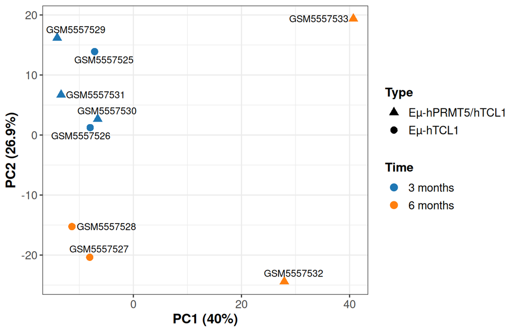

```r
# Variance stabilised transformation
vsdata <- vst(dds, blind = FALSE)

# Extract matrix
vs_mat <- assay(vsdata)

# Adjust for batch (assume batch info is in colData(dds)$batch)
vs_mat_corrected <- removeBatchEffect(vs_mat, batch = colData(dds)$batch)

# PCA on corrected data
pca <- prcomp(t(vs_mat_corrected))

# Calculate % variance explained
pca_var <- pca$sdev^2               # variance of each PC
pca_var_percent <- pca_var / sum(pca_var) * 100

# Create case name
case <- sub("^0*", "", sub("-.*$", "", rownames(colData(dds))))

# Make a dataframe for ggplot
pca_df <- data.frame(pca$x,
                     condition = colData(dds)$condition,
                     sample = case)

# Split into 'type' and 'time'
pca_df$type <- ifelse(grepl("PRMT5", pca_df$condition), "Eµ-hPRMT5/hTCL1", "Eµ-hTCL1")
pca_df$time <- ifelse(grepl("3months", pca_df$condition), "3 months", "6 months")

# Set factor levels for ordering in legend
pca_df$condition <- factor(
  pca_df$condition,
  levels = c("Eµ-hTCL1 - 3months",
             "Eµ-hPRMT5/hTCL1 - 3months",
             "Eµ-hTCL1 - 6months",
             "Eµ-hPRMT5/hTCL1 - 6months")
)

# Plot PCA
pca.plt <- ggplot(pca_df, aes(PC1, PC2, color = time, shape = type, label = sample)) +
  geom_point(size = 3) +
  geom_text_repel(size = 3.25, color = "black") +
  xlab(paste0("PC1 (", round(pca_var_percent[1], 1), "%)")) +
  ylab(paste0("PC2 (", round(pca_var_percent[2], 1), "%)")) +
  scale_color_manual(values = c("3 months" = "#1f77b4", "6 months" = "#ff7f0e")) +
  scale_shape_manual(values = c("Eµ-hTCL1" = 16, "Eµ-hPRMT5/hTCL1" = 17)) +
  guides(
    color = guide_legend(title = "Time"),
    shape = guide_legend(title = "Type")
  ) +
  theme_bw() +
  theme(
    legend.title = element_text(size = 12, face = "bold"),
    legend.text = element_text(size = 11),
    axis.title = element_text(size = 13, face = "bold"),
    axis.text = element_text(size = 11)
  )

pca.plt
```

After batch correction using `limma()`, the sample in 3 months cannot be seprated while in 6 months the samples between Eµ-hTCL1 and Eµ-hPRMT5/hTCL1 were clearly separated.

## Differential gene expression analysis (DEA)

We will compare DEA between `Eµ-hPRMT5/hTCL1 - 6months` group and others.

```r
# Create the object and colData based on group (RT and others) instead of condition
dds <- DESeqDataSetFromTximport(txi, colData, ~ group)

# Keep genes with at least 10 counts across all samples
keep <- rowSums(counts(dds)) >= 10
dds <- dds[keep,]

# Run DESeq2
dds$condition <- relevel(dds$group, ref = "Others")
dds <- DESeq(dds)
```

```r
# Generate a table for gene expression
res <- lfcShrink(dds, contrast = c("group", "RT", "Others"), type = "normal")
head(res)
```

```
log2 fold change (MAP): group RT vs Others
Wald test p-value: group RT vs Others
DataFrame with 6 rows and 6 columns
                     baseMean log2FoldChange     lfcSE      stat    pvalue
                    <numeric>      <numeric> <numeric> <numeric> <numeric>
ENSMUSG00000000001 2451.37346       0.261320  0.153331  1.704264 0.0883317
ENSMUSG00000000028  141.34323       0.631486  0.346307  1.818656 0.0689639
ENSMUSG00000000037    2.83126      -0.315802  0.426414 -0.924609 0.3551695
ENSMUSG00000000056  568.70809      -0.277502  0.190849 -1.453976 0.1459529
ENSMUSG00000000058   15.03995       0.235126  0.462686  0.499442 0.6174680
ENSMUSG00000000078 2378.89480       0.137630  0.241980  0.568696 0.5695623
                        padj
                   <numeric>
ENSMUSG00000000001  0.215815
ENSMUSG00000000028  0.181686
ENSMUSG00000000037        NA
ENSMUSG00000000056  0.307310
ENSMUSG00000000058  0.771144
ENSMUSG00000000078  0.736662
```

### Convert mouse to human ensemble ids

```r
# Get orthologs
path_to_ortholog <- str_c(path_to_ref_transcriptome, "/mouse_human_ortholog.txt")
orthologs <- read.csv(path_to_ortholog)
head(orthologs)
```

```
   Gene.stable.ID Gene.stable.ID.version Mouse.gene.stable.ID Mouse.gene.name
1 ENSG00000198888      ENSG00000198888.2   ENSMUSG00000064341          mt-Nd1
2 ENSG00000198763      ENSG00000198763.3   ENSMUSG00000064345          mt-Nd2
3 ENSG00000198804      ENSG00000198804.2   ENSMUSG00000064351          mt-Co1
4 ENSG00000198712      ENSG00000198712.1   ENSMUSG00000064354          mt-Co2
5 ENSG00000228253      ENSG00000228253.1   ENSMUSG00000064356         mt-Atp8
6 ENSG00000198899      ENSG00000198899.2   ENSMUSG00000064357         mt-Atp6
  Gene.name
1    MT-ND1
2    MT-ND2
3    MT-CO1
4    MT-CO2
5   MT-ATP8
6   MT-ATP6
```

```r
# Use left_join to convert mouse to human ensembl ids
human_res <- as.data.frame(res) %>%
  rownames_to_column("Mouse_Ensembl_ID") %>%
  left_join(orthologs, by = c("Mouse_Ensembl_ID" = "Mouse.gene.stable.ID"))

head(human_res)
```

```
    Mouse_Ensembl_ID    baseMean log2FoldChange     lfcSE       stat     pvalue
1 ENSMUSG00000000001 2451.373462      0.2613198 0.1533307  1.7042642 0.08833175
2 ENSMUSG00000000028  141.343231      0.6314858 0.3463069  1.8186562 0.06896390
3 ENSMUSG00000000037    2.831259     -0.3158021 0.4264135 -0.9246087 0.35516950
4 ENSMUSG00000000056  568.708091     -0.2775015 0.1908494 -1.4539763 0.14595287
5 ENSMUSG00000000058   15.039953      0.2351262 0.4626862  0.4994421 0.61746797
6 ENSMUSG00000000078 2378.894799      0.1376302 0.2419805  0.5686962 0.56956234
       padj  Gene.stable.ID Gene.stable.ID.version Mouse.gene.name Gene.name
1 0.2158146 ENSG00000065135     ENSG00000065135.13           Gnai3     GNAI3
2 0.1816864 ENSG00000093009     ENSG00000093009.12           Cdc45     CDC45
3        NA ENSG00000102098     ENSG00000102098.20           Scml2     SCML2
4 0.3073105 ENSG00000141562     ENSG00000141562.20            Narf      NARF
5 0.7711440 ENSG00000105971     ENSG00000105971.16            Cav2      CAV2
6 0.7366616 ENSG00000067082     ENSG00000067082.16            Klf6      KLF6
```

```r
# Save the expression result
saveRDS(human_res, path_to_save_dea)
```

## Plot heatmap of gene expression

```r
# Import the relevant package
library(pheatmap)
library(RColorBrewer)
```

```r
# Data transformation
vsd <- vst(dds, blind=FALSE)       # Variance-stabilizing transformation
#rld <- rlog(dds_filtered, blind=FALSE)      # Regularized log transformation

# Extract transformed expression matrix
expr_mat <- assay(vsd)

# Calculate z-scores
zscore_mat <- t(scale(t(expr_mat)))
```

```r
# Extract main and sub- clusters info from column names
prmt5_sample <- colData[which(grepl("PRMT5", colData$condition)), "samples"]
sixmonths_sample <- colData[which(grepl("6months", colData$condition)), "samples"]
conditions <-  ifelse(colnames(zscore_mat) %in% prmt5_sample, "Eµ-hPRMT5/hTCL1", "Eµ-hTCL1")
times <- ifelse(colnames(zscore_mat) %in% sixmonths_sample, "6m", "3m")

# Create annotation dataframe
annotation_col <- data.frame(
  Condition = factor(conditions, levels = c("Eµ-hTCL1", "Eµ-hPRMT5/hTCL1")),
  Time = factor(times, levels = c("3m", "6m"))
)
annotation_col <- annotation_col[, c("Time", "Condition"), drop = FALSE]
rownames(annotation_col) <- colnames(zscore_mat)

# Order by Condition and then Time
order_cols <- order(annotation_col$Condition, annotation_col$Time)
zscore_mat_ordered <- zscore_mat[, order_cols]
annotation_col_ordered <- annotation_col[order_cols, , drop = FALSE]
```

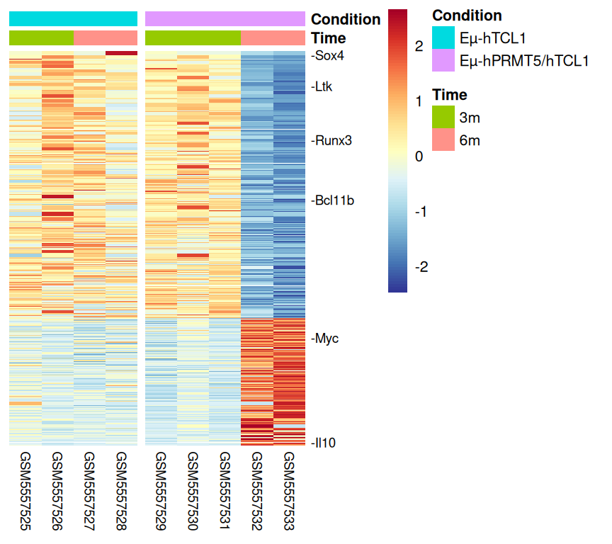

```r
# Genes of interest
genes_of_interest <- c("Sox4", "Bcl11b", "Ltk", "Runx3", "Myc", "Il10")

# Filter for significant DE genes
sig_genes <- human_res[!is.na(human_res$padj) & human_res$padj < 0.05 & abs(human_res$log2FoldChange) > 1, ]

# Order genes by log2FoldChange (descending: up -> down)
gene_order <- sig_genes$Mouse_Ensembl_ID[order(sig_genes$log2FoldChange, decreasing = FALSE)]

# Subset zscore matrix
zscore_mat_sig <- zscore_mat_ordered[gene_order, ]

# Labrl row names
rownames(zscore_mat_sig) <- human_res$Mouse.gene.name[match(rownames(zscore_mat_sig), human_res$Mouse_Ensembl_ID)]
gene_labels <- ifelse(rownames(zscore_mat_sig) %in% genes_of_interest,
                      str_c("-", rownames(zscore_mat_sig)), "")

# Plot heatmap
pheatmap(
  zscore_mat_sig,
  labels_row = gene_labels,
  cluster_rows = FALSE,
  cluster_cols = FALSE,
  show_rownames = TRUE,
  color = colorRampPalette(rev(brewer.pal(11, "RdYlBu")))(100),
  annotation_col = annotation_col_ordered,
  fontsize = 8,
  fontsize_row = 7,
  fontsize_col = 7,
  gaps_col = which(diff(as.numeric(factor(annotation_col_ordered$Condition))) != 0)
)
```

# Gene Set Enrichment Analysis (GSEA)

```r
# Import the related libraries in functional enrichment analysis
library(clusterProfiler)
library(enrichplot)
library(msigdbr)
library(org.Hs.eg.db)
```

```r
# Manipulate the expression data
dea <- human_res[!is.na(human_res$Gene.stable.ID), ]
lfc_vector <- dea$log2FoldChange # Create a named vector ranked based on the log2 fold change
names(lfc_vector) <- dea$Gene.stable.ID
lfc_vector <- na.omit(lfc_vector) # Omit any NA values
lfc_vector <- sort(lfc_vector, decreasing = TRUE) # Sort the log2 fold change in descending order
lfc_vector <- lfc_vector[!duplicated(names(lfc_vector))]
```

### Hallmark

```r
# Hallmark
HM_gsea <- HM_GSEA(lfc_vector, gene_ident = "ensembl_gene")

# Collect the HM GSEA result
HM_GSEA.result <- HM_gsea@result
HM_GSEA_selected.result <- HM_GSEA.result %>%
  as_tibble() %>%
  dplyr::select(c(Description, NES, pvalue, p.adjust))

DT::datatable(HM_GSEA_selected.result, options = list(scrollX = TRUE))
```

|  | Description | NES | pvalue | p.adjust |
| --- | --- | --- | --- | --- |
| 1 | HALLMARK_MYC_TARGETS_V1 | 2.656676080060544 | 4.148980928507755e-21 | 2.0330006549688e-19 |
| 2 | HALLMARK_E2F_TARGETS | 2.599631867455325 | 1.540660203453909e-20 | 3.774617498462078e-19 |
| 3 | HALLMARK_G2M_CHECKPOINT | 2.407139898124166 | 2.402138343947004e-15 | 3.923492628446773e-14 |
| 4 | HALLMARK_OXIDATIVE_PHOSPHORYLATION | 2.072490973432192 | 1.96679542295005e-09 | 2.409324393113811e-08 |
| 5 | HALLMARK_MYC_TARGETS_V2 | 2.25564309626633 | 2.140684430072209e-07 | 2.097870741470764e-06 |
| 6 | HALLMARK_ALLOGRAFT_REJECTION | -1.946420731423812 | 3.017656936913323e-07 | 2.464419831812547e-06 |
| 7 | HALLMARK_MTORC1_SIGNALING | 1.728976751235097 | 1.609273252050841e-05 | 0.0001126491276435589 |
| 8 | HALLMARK_DNA_REPAIR | 1.774059842675351 | 7.351399688197454e-05 | 0.0004502732309020941 |
| 9 | HALLMARK_UNFOLDED_PROTEIN_RESPONSE | 1.780363717394422 | 0.0001881983022072834 | 0.001024635200906321 |
| 10 | HALLMARK_GLYCOLYSIS | 1.628061885148239 | 0.0004428277521450016 | 0.002169855985510508 |

[output cut: 5 more lines]

We will explore the trends of hallmark terms reported from other single-cell pseudobulk studies such as Nadeu et al. (2022) and Hing et al (2023). From those studies, the terms such as E2F targets, Myc targets, and oxidative phosphorylation (OXPHOS) were upregulated.

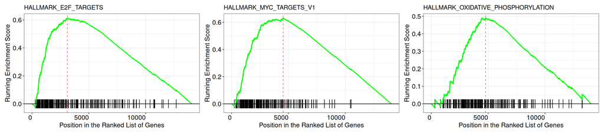

```r
# GSEA plot for HALLMARK_E2F_TARGETS, HALLMARK_MYC_TARGETS_V1, and HALLMARK_OXIDATIVE_PHOSPHORYLATION

E2F_gsea.plt <- gseaplot(HM_gsea,
                          by = "runningScore",
                          title = "HALLMARK_E2F_TARGETS",
                          geneSetID = "HALLMARK_E2F_TARGETS",
                          base_size = 10) +
  theme(axis.text.x = element_text(angle = 0, hjust = 1))

Myc_gsea.plt <- gseaplot(HM_gsea,
                          by = "runningScore",
                          title = "HALLMARK_MYC_TARGETS_V1",
                          geneSetID = "HALLMARK_MYC_TARGETS_V1",
                          base_size = 10) +
  theme(axis.text.x = element_text(angle = 0, hjust = 1))

OXPHOS_gsea.plt <- gseaplot(HM_gsea,
                          by = "runningScore",
                          title = "HALLMARK_OXIDATIVE_PHOSPHORYLATION",
                          geneSetID = "HALLMARK_OXIDATIVE_PHOSPHORYLATION",
                          base_size = 10) +
  theme(axis.text.x = element_text(angle = 0, hjust = 1))

E2F_gsea.plt + Myc_gsea.plt + OXPHOS_gsea.plt
```

### GO:BP

```r
# GO:BP
GOBP_gsea <- GO_GSEA(lfc_vector, gene_ident = "ensembl_gene")

# Collect the GSEA result
GOBP_GSEA.result <- GOBP_gsea@result
GOBP_GSEA_selected.result <- GOBP_GSEA.result %>%
  as_tibble() %>%
  dplyr::select(c(Description, NES, pvalue, p.adjust))

DT::datatable(GOBP_GSEA_selected.result, options = list(scrollX = TRUE))
```

|  | Description | NES | pvalue | p.adjust |
| --- | --- | --- | --- | --- |
| 1 | GOBP_RIBOSOME_BIOGENESIS | 2.239980100218558 | 1.256766060234701e-14 | 3.329173293561722e-11 |
| 2 | GOBP_RIBONUCLEOPROTEIN_COMPLEX_BIOGENESIS | 2.075156735328667 | 7.029883784315285e-14 | 9.311081072325596e-11 |
| 3 | GOBP_RRNA_METABOLIC_PROCESS | 2.179993806824503 | 3.446428019730641e-12 | 2.290192870126119e-09 |
| 4 | GOBP_T_CELL_ACTIVATION | -1.922582287342631 | 3.458199879390139e-12 | 2.290192870126119e-09 |
| 5 | GOBP_SENSORY_PERCEPTION_OF_SMELL | -2.304798851654883 | 4.808969329856709e-12 | 2.547791950958084e-09 |
| 6 | GOBP_T_CELL_RECEPTOR_SIGNALING_PATHWAY | -2.438402816210366 | 8.121982006723234e-12 | 3.585855055968308e-09 |
| 7 | GOBP_RRNA_PROCESSING | 2.165145353713011 | 2.750760493676599e-11 | 1.040966363964187e-08 |
| 8 | GOBP_T_CELL_DIFFERENTIATION | -1.964689093263971 | 1.775149772120194e-09 | 5.877964682932991e-07 |
| 9 | GOBP_MITOTIC_SISTER_CHROMATID_SEGREGATION | 2.09583569899077 | 2.845609512917685e-09 | 8.375577333021052e-07 |
| 10 | GOBP_CHROMOSOME_SEGREGATION | 1.878793027390232 | 4.705239471372965e-09 | 1.246417935966698e-06 |

[output cut: 316 more lines]

We will also explore the trends of GO:BP terms reported from other single-cell studies such as Nadeu et al. (2022) and Hing et al (2023). From those studies, the terms such as OXPHOS and mitochondrial translation were upregulated while BCR signalling was downregulated.

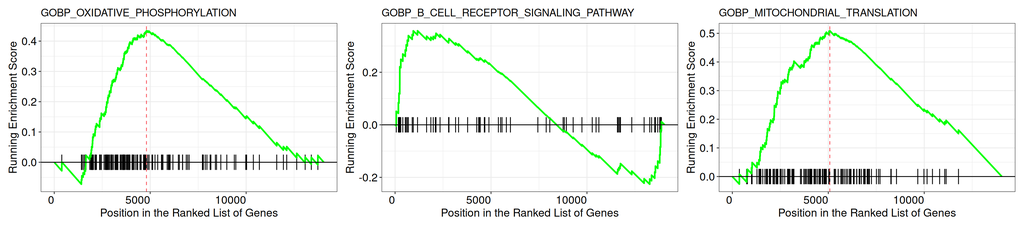

```r
# GSEA plot for GOBP_OXIDATIVE_PHOSPHORYLATION, GOBP_B_CELL_RECEPTOR_SIGNALING_PATHWAY, and GOBP_MITOCHONDRIAL_TRANSLATION

OXPHOS_GO_gsea.plt <- gseaplot(GOBP_gsea,
                          by = "runningScore",
                          title = "GOBP_OXIDATIVE_PHOSPHORYLATION",
                          geneSetID = "GOBP_OXIDATIVE_PHOSPHORYLATION",
                          base_size = 10) +
  theme(axis.text.x = element_text(angle = 0, hjust = 1))

BCR_GO_gsea.plt <- gseaplot(GOBP_gsea,
                          by = "runningScore",
                          title = "GOBP_B_CELL_RECEPTOR_SIGNALING_PATHWAY",
                          geneSetID = "GOBP_B_CELL_RECEPTOR_SIGNALING_PATHWAY",
                          base_size = 10) +
  theme(axis.text.x = element_text(angle = 0, hjust = 1))

mitochondrial_GO_gsea.plt <- gseaplot(GOBP_gsea,
                          by = "runningScore",
                          title = "GOBP_MITOCHONDRIAL_TRANSLATION",
                          geneSetID = "GOBP_MITOCHONDRIAL_TRANSLATION",
                          base_size = 10) +
  theme(axis.text.x = element_text(angle = 0, hjust = 1))

OXPHOS_GO_gsea.plt + BCR_GO_gsea.plt + mitochondrial_GO_gsea.plt
```

We also performed GSEA with additional enrichment systems such as KEGG pathways, Reactome, and WikiPath.

### KEGG pathway

```r
# KEGG pathway
KEGG_gsea <- KEGG_GSEA(lfc_vector, gene_ident = "ensembl_gene")

# Collect the HM GSEA result
KEGG_GSEA.result <- KEGG_gsea@result
KEGG_GSEA_selected.result <- KEGG_GSEA.result %>%
  as_tibble() %>%
  dplyr::select(c(Description, NES, pvalue, p.adjust))

DT::datatable(KEGG_GSEA_selected.result, options = list(scrollX = TRUE))
```

|  | Description | NES | pvalue | p.adjust |
| --- | --- | --- | --- | --- |
| 1 | KEGG_OLFACTORY_TRANSDUCTION | -2.216072780570573 | 2.70615933266379e-10 | 3.734499879076031e-08 |
| 2 | KEGG_T_CELL_RECEPTOR_SIGNALING_PATHWAY | -2.24660568865753 | 5.584146769530473e-09 | 3.853061270976026e-07 |
| 3 | KEGG_HEMATOPOIETIC_CELL_LINEAGE | -2.292977441515739 | 1.619378433941494e-07 | 7.449140796130874e-06 |
| 4 | KEGG_OXIDATIVE_PHOSPHORYLATION | 2.016560038349068 | 7.620287168334611e-07 | 2.628999073075441e-05 |
| 5 | KEGG_ARGININE_AND_PROLINE_METABOLISM | 2.120023761759762 | 8.572617290254069e-06 | 0.0002086966717315243 |
| 6 | KEGG_CYTOKINE_CYTOKINE_RECEPTOR_INTERACTION | -1.765310118371263 | 9.073768336153233e-06 | 0.0002086966717315243 |
| 7 | KEGG_NEUROACTIVE_LIGAND_RECEPTOR_INTERACTION | -1.855957522720704 | 2.174145307338966e-05 | 0.0004286172177325389 |
| 8 | KEGG_PYRIMIDINE_METABOLISM | 1.947615433671988 | 3.569011534497907e-05 | 0.0005864848979507278 |
| 9 | KEGG_PARKINSONS_DISEASE | 1.845559700892797 | 3.824901508374312e-05 | 0.0005864848979507278 |
| 10 | KEGG_CELL_CYCLE | 1.827690309136028 | 6.386539368597649e-05 | 0.0008813424328664756 |

[output cut: 16 more lines]

### Reactome

```r
# REACTOME
REACTOME_gsea <- REACTOME_GSEA(lfc_vector, gene_ident = "ensembl_gene")

# Collect the HM GSEA result
REACTOME_GSEA.result <- REACTOME_gsea@result
REACTOME_GSEA_selected.result <- REACTOME_GSEA.result %>%
  as_tibble() %>%
  dplyr::select(c(Description, NES, pvalue, p.adjust))

DT::datatable(REACTOME_GSEA_selected.result, options = list(scrollX = TRUE))
```

|  | Description | NES | pvalue | p.adjust |
| --- | --- | --- | --- | --- |
| 1 | REACTOME_M_PHASE | 2.349599604126718 | 6.955711614976966e-20 | 4.945510958248623e-17 |
| 2 | REACTOME_TRANSLATION | 2.426089549129528 | 6.735055124477799e-18 | 2.394312096751857e-15 |
| 3 | REACTOME_CELL_CYCLE_CHECKPOINTS | 2.332987209552126 | 5.157191514878904e-16 | 1.2222543890263e-13 |
| 4 | REACTOME_MITOTIC_METAPHASE_AND_ANAPHASE | 2.383065963387477 | 1.673407023841113e-15 | 2.974480984877578e-13 |
| 5 | REACTOME_SEPARATION_OF_SISTER_CHROMATIDS | 2.369632316694645 | 8.806765174391446e-14 | 1.252322007798463e-11 |
| 6 | REACTOME_MITOTIC_PROMETAPHASE | 2.244194213982377 | 5.603059483731253e-12 | 6.639625488221535e-10 |
| 7 | REACTOME_RRNA_PROCESSING | 2.269301372662529 | 1.089773589407596e-11 | 1.10689860295543e-09 |
| 8 | REACTOME_GENERATION_OF_SECOND_MESSENGER_MOLECULES | -2.602120188296445 | 5.47409531791476e-11 | 4.663099859544344e-09 |
| 9 | REACTOME_RESOLUTION_OF_SISTER_CHROMATID_COHESION | 2.324775523181284 | 5.902658050056131e-11 | 4.663099859544344e-09 |
| 10 | REACTOME_OLFACTORY_SIGNALING_PATHWAY | -2.22991545336215 | 8.353738003791437e-11 | 5.939507720695711e-09 |

[output cut: 188 more lines]

### WikiPath

```r
# WikiPath
WIKIPATH_gsea <- WIKIPATH_GSEA(lfc_vector, gene_ident = "ensembl_gene")

# Collect the HM GSEA result
WIKIPATH_GSEA.result <- WIKIPATH_gsea@result
WIKIPATH_GSEA_selected.result <- WIKIPATH_GSEA.result %>%
  as_tibble() %>%
  dplyr::select(c(Description, NES, pvalue, p.adjust))

DT::datatable(WIKIPATH_GSEA_selected.result, options = list(scrollX = TRUE))
```

|  | Description | NES | pvalue | p.adjust |
| --- | --- | --- | --- | --- |
| 1 | WP_MODULATORS_OF_TCR_SIGNALING_AND_T_CELL_ACTIVATION | -2.384109300195222 | 4.492708224283158e-09 | 1.702736417003317e-06 |
| 2 | WP_ELECTRON_TRANSPORT_CHAIN_OXPHOS_SYSTEM_IN_MITOCHONDRIA | 2.154843424158241 | 1.458967966763985e-07 | 1.843162864678501e-05 |
| 3 | WP_TCELL_RECEPTOR_SIGNALING | -2.120989432655784 | 1.406979659844891e-07 | 1.843162864678501e-05 |
| 4 | WP_SELECTIVE_EXPRESSION_OF_CHEMOKINE_RECEPTORS_DURING_TCELL_POLARIZATION | -2.312236389240124 | 4.026537009065301e-07 | 3.795671111857298e-05 |
| 5 | WP_TCELL_ACTIVATION_SARSCOV2 | -2.154514538445908 | 6.008978013494403e-07 | 3.795671111857298e-05 |
| 6 | WP_GPCRS_CLASS_A_RHODOPSINLIKE | -1.977777344640319 | 5.854034145622446e-07 | 3.795671111857298e-05 |
| 7 | WP_PARKINUBIQUITIN_PROTEASOMAL_SYSTEM_PATHWAY | 2.16467896323482 | 8.597619717842414e-07 | 4.580511905547917e-05 |
| 8 | WP_TH17_CELL_DIFFERENTIATION_PATHWAY | -2.10387694621452 | 9.668626713557608e-07 | 4.580511905547917e-05 |
| 9 | WP_TGFBETA_RECEPTOR_SIGNALING_IN_SKELETAL_DYSPLASIAS | -2.189792627711927 | 1.173864854541662e-06 | 4.943275331903221e-05 |
| 10 | WP_TGFBETA_RECEPTOR_SIGNALING | -2.135392793956448 | 4.790447130242111e-06 | 0.0001747695984284587 |

[output cut: 36 more lines]

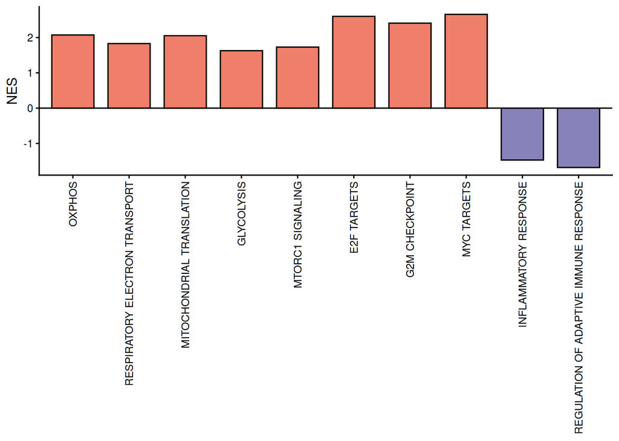

```r
# Bar plot of GSEA
gsea_bp <- rbind(HM_GSEA_selected.result[HM_GSEA_selected.result$Description == "HALLMARK_OXIDATIVE_PHOSPHORYLATION",],
                 REACTOME_GSEA_selected.result[REACTOME_GSEA_selected.result$Description ==
                                                 "REACTOME_AEROBIC_RESPIRATION_AND_RESPIRATORY_ELECTRON_TRANSPORT",],
                 GOBP_GSEA_selected.result[GOBP_GSEA_selected.result$Description == "GOBP_MITOCHONDRIAL_TRANSLATION",],
                 HM_GSEA_selected.result[HM_GSEA_selected.result$Description == "HALLMARK_GLYCOLYSIS",],
                 HM_GSEA_selected.result[HM_GSEA_selected.result$Description == "HALLMARK_MTORC1_SIGNALING",],
                 HM_GSEA_selected.result[HM_GSEA_selected.result$Description == "HALLMARK_E2F_TARGETS",],
                 HM_GSEA_selected.result[HM_GSEA_selected.result$Description == "HALLMARK_G2M_CHECKPOINT",],
                 HM_GSEA_selected.result[HM_GSEA_selected.result$Description == "HALLMARK_MYC_TARGETS_V1",],
                 HM_GSEA_selected.result[HM_GSEA_selected.result$Description == "HALLMARK_INFLAMMATORY_RESPONSE",],
                 GOBP_GSEA_selected.result[GOBP_GSEA_selected.result$Description == "GOBP_REGULATION_OF_ADAPTIVE_IMMUNE_RESPONSE",],
                 KEGG_GSEA_selected.result[KEGG_GSEA_selected.result$Description == "KEGG_TOLL_LIKE_RECEPTOR_SIGNALING_PATHWAY",],
                 REACTOME_GSEA_selected.result[REACTOME_GSEA_selected.result$Description ==
                                                 "REACTOME_SIGNALING_BY_THE_B_CELL_RECEPTOR_BCR",]
                 )

gsea_bp$Description <- gsub("HALLMARK_", "", gsea_bp$Description)
gsea_bp$Description <- gsub("GOBP_", "", gsea_bp$Description)
gsea_bp$Description <- gsub("KEGG_", "", gsea_bp$Description)
gsea_bp$Description <- gsub("REACTOME_", "", gsea_bp$Description)
gsea_bp$Description <- gsub("WP_", "", gsea_bp$Description)
gsea_bp$Description <- gsub("_V1", "", gsea_bp$Description)
gsea_bp$Description <- gsub("OXIDATIVE_PHOSPHORYLATION", "OXPHOS", gsea_bp$Description)
gsea_bp$Description <- gsub("AEROBIC_RESPIRATION_AND_RESPIRATORY_ELECTRON_TRANSPORT", "RESPIRATORY_ELECTRON_TRANSPORT", gsea_bp$Description)
gsea_bp$Description <- gsub("SIGNALING_BY_THE_B_CELL_RECEPTOR_BCR", "BCR_PATHWAY", gsea_bp$Description)
gsea_bp$Description <- gsub("_V1", "", gsea_bp$Description)
gsea_bp$Description <- gsub("_", " ", gsea_bp$Description)

gsea_bp$Description <- factor(gsea_bp$Description, levels = gsea_bp$Description)
gsea_bp$Direction <- "Up"
gsea_bp$Direction[gsea_bp$NES<0] <- "Down"

gsea_bar.plt <- ggplot(gsea_bp, aes(x=Description, y=NES, fill=Direction)) +
  geom_bar(stat = "identity", color="black", width = 0.75) +
  theme_classic() +
  theme(axis.text.x = element_text(angle = 90, vjust = 0.5, hjust=1)) +
  geom_hline(yintercept = 0) +
  ylab("NES") + xlab(NULL) +
  scale_fill_manual(values=c("#8882BA", "#EF7F6A")) + theme(legend.position = "none")

gsea_bar.plt
```

```r
# Save gene expression and GSEA data
saveRDS(HM_gsea, path_to_save_hm_gsea)
saveRDS(GOBP_gsea, path_to_save_go_gsea)
saveRDS(KEGG_gsea, path_to_save_kegg_gsea)
saveRDS(REACTOME_gsea, path_to_save_reactome_gsea)
saveRDS(WIKIPATH_gsea, path_to_save_wikipath_gsea)
```